# Exercises 1.9-1.15

Aleksandra Kilijańska

2023-04-18

## 1.9 (Custom standard deviation function).

Write a function sd.n similar to the function var.n in Example 1.5 that will return the estimate σˆ (the square root of σˆ2). Try this function on the temperature data of Example 1.1.

```r
sd.n = function(x) {
  n = length(x)
  if (n == 1) {
    stop("Need at least two data points")
  }
  m = mean(x)
  s = sqrt(sum((x - m)^2) / (n - 1))
  return(s)
}

temps = c(51.9, 51.8, 51.9, 53)
sd.n(temps)
```

```
## [1] 0.5686241
```

## 1.10 (Euclidean norm function).

Write a function norm that will compute the Euclidean norm of a numeric vector. The Euclidean norm of a vector x = (x1,…,xn) is… Use vectorized operations to compute the sum. Try this function on the vectors (0,0,0,1) and (2,5,2,4) to check that your function result is correct.

```r
norm = function(x){

  return(sqrt(sum(x^2)))
}

v1=c(0,0,0,1)
norm(v1)
```

```
## [1] 1
```

```r
v2=c(2,5,2,4)
norm(v2)
```

```
## [1] 7
```

## 1.11 (Numerical integration).

Use the curve function to display the graph of the function f(x) = e−x2 /(1 +x2) on the interval 0 ≤ x ≤ 10. Then use the integrate function to compute the value of the integral. The upper limit at infinity is specified by upper=Inf in the integrate function.

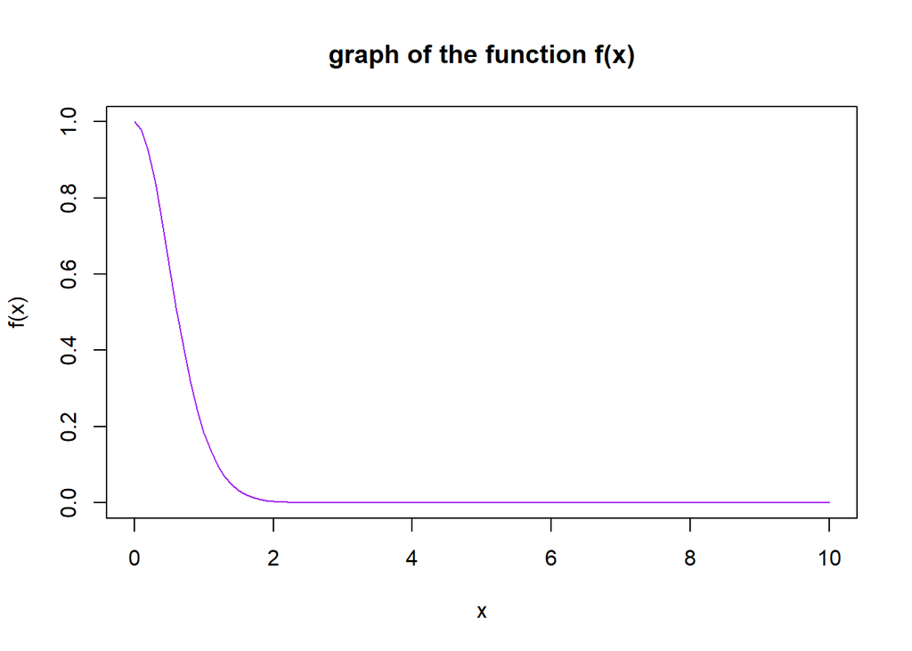

```r
f = function(x) exp(-x^2) / (1 + x^2)
curve(f, 0, 10, ylab = "f(x)", xlab = "x", main="graph of the function f(x)", col="purple")
```

```r
integrate(f,0,Inf)
```

```
## 0.6716467 with absolute error < 8.3e-05
```

## 1.12 (Bivariate normal).

Construct a matrix with 10 rows and 2 columns, containing random standard normal data: x = matrix(rnorm(20), 10, 2) This is a random sample of 10 observations from a standard bivariate normal distribution. Use the apply function and your norm function from Exercise 1.10 to compute the Euclidean norms for each of these 10 observations.

```r
x = matrix(rnorm(20), 10, 2)
norms = apply(x, 1, norm)

print(norms)
```

```
##  [1] 1.2826411 1.2184727 0.7783245 0.3232820 0.4445842 0.7210525 0.4187526
##  [8] 0.4546598 1.2440703 0.7569232
```

## 1.13 (lunatics data).

Obtain a five-number summary for the numeric variables in the lunatics data set (see Example 1.12). From the summary we can get an idea about the skewness of variables by comparing the median and the mean population. Which of the distributions are skewed, and in which direction?

```r
library(BaM)
data(lunatics)
lunatics
```

```
##        COUNTY NBR DIST     POP PDEN PHOME
## 1   BERKSHIRE 119   97  26.656   56    77
## 2    FRANKLIN  84   62  22.260   45    81
## 3   HAMPSHIRE  94   54  23.312   72    75
## 4     HAMPDEN 105   52  18.900   94    69
## 5   WORCESTER 351   20  82.836   98    64
## 6   MIDDLESEX 357   14  66.759  231    47
## 7       ESSEX 377   10  95.004 3252    47
## 8     SUFFOLK 458    4 123.202 3042     6
## 9     NORFOLK 241   14  62.901  235    49
## 10    BRISTOL 158   14  29.704  151    60
## 11   PLYMOUTH 139   16  32.526   91    68
## 12 BARNSTABLE  78   44  16.692   93    76
## 13  NANTUCKET  12   77   1.740  179    25
## 14      DUKES  19   52   7.524   46    79
```

```r
summary(lunatics[2:6])
```

```
##       NBR             DIST            POP              PDEN
##  Min.   : 12.0   Min.   : 4.00   Min.   :  1.74   Min.   :  45.00
##  1st Qu.: 86.5   1st Qu.:14.00   1st Qu.: 19.74   1st Qu.:  76.75
##  Median :129.0   Median :32.00   Median : 28.18   Median :  96.00
##  Mean   :185.1   Mean   :37.86   Mean   : 43.57   Mean   : 548.93
##  3rd Qu.:323.5   3rd Qu.:53.50   3rd Qu.: 65.79   3rd Qu.: 218.00
##  Max.   :458.0   Max.   :97.00   Max.   :123.20   Max.   :3252.00
##      PHOME
##  Min.   : 6.00
##  1st Qu.:47.50
##  Median :66.00
##  Mean   :58.79
##  3rd Qu.:75.75
##  Max.   :81.00
```

## 1.14 (Tearing factor of paper).

The following data describe the tearing factor of paper manufactured under different pressures during pressing. The data is given in Hand et al. [21, Page 4]. Four sheets of paper were selected and tested from each of the five batches manufactured.

Enter this data into an R data frame with two variables: tear factor and pressure. Hint: it may be easiest to enter it into a spreadsheet, and then save it as a tab or comma delimited file (.txt or .csv). There should be 20 observations after a successful import.

```r
tear_factor <- c(112, 119, 117, 113, 108, 99, 112, 118, 120,
      106, 102, 109, 110, 101, 99, 104, 100, 102, 96, 101)
pressure <- rep(c(35.0, 49.5, 70.0, 99.0, 140.0), each = 4)
paper_data <- data.frame(pressure, tear_factor)
paper_data
```

```
##    pressure tear_factor
## 1      35.0         112
## 2      35.0         119
## 3      35.0         117
## 4      35.0         113
## 5      49.5         108
## 6      49.5          99
## 7      49.5         112
## 8      49.5         118
## 9      70.0         120
## 10     70.0         106
## 11     70.0         102
## 12     70.0         109
## 13     99.0         110
## 14     99.0         101
## 15     99.0          99
## 16     99.0         104
## 17    140.0         100
## 18    140.0         102
## 19    140.0          96
## 20    140.0         101
```

## 1.15 (Vectorized operations).

We have seen two examples of vectorized arithmetic in Example 1.1. In the conversion to Celsius, the operations involved one vector temps of length four and scalars (32 and 5/9). When we computed differences, the operation involved two vectors temps and CT of length four. In both cases, the arithmetic operations were applied element by element. What would happen if two vectors of different lengths appear together in an arithmetic expression? Try the following examples using the colon operator : to generate a sequence of consecutive integers.

a:

```r
x = 1:8
n = 1:2
x+n
```

```
## [1]  2  4  4  6  6  8  8 10
```

R repeats the shorter vector as many times as necessary until its length is the same as the longer vector.

b:

```r
n = 1:3
x+n
```

```
## Warning in x + n: długość dłuszego obiektu nie jest wielokrotnością długości
## krótszego obiektu
```

```
## [1]  2  4  6  5  7  9  8 10
```

R repeats the shorter vector as many times as necessary until its length is the same as the longer vector, but in this case, throws a warning because longer vector length is not a multiple of shorter vector.